# Aprendizaje incremental con series temporales

### Informe técnico del Trabajo Final de Máster

### Autor: Sergi Payarol Calzado

### Fecha: 15/11/2024

[figure not shown]

**Tabla de contenido**

- 1. Introducción
  - 1.1 Importación de librerías
- 2. Métodos
- 3. Aprendizaje incremental
  - 3.1 SNARIMAX
    - 3.1.1 Predicción sin exógenas y sin monitorizar el drift
    - 3.1.2 Predicción sin exógenas y monitorizando el drift con ADWIN
    - 3.1.3 Predicción con 4 exógenas y monitorizando el drift con ADWIN
    - 3.1.4 Predicción con 3 exógenas y monitorizando el drift con ADWIN
    - 3.1.5 Predicción con 3 exógenas sin monitorizar el drift
    - 3.1.6 Predicción con 3 exógenas monitorizando el drift con KSWIN
  - 3.2 Holt Winters
    - 3.2.1 Predicción con 3 exógenas sin monitorización del drift
- 4. Resultados
- 5. Conclusiones

# 1. Introducción

El aprendizaje incremental en series temporales se centra en actualizar los modelos de predicción a medida que se incorporan nuevos datos, permitiendo una adaptación continua al entorno cambiante. Este enfoque es especialmente relevante en dominios donde las características del sistema pueden evolucionar, como los mercados financieros.

En este apartado, exploramos diversas configuraciones de aprendizaje incremental utilizando modelos de series temporales. El objetivo principal es evaluar cómo diferentes combinaciones de factores exógenos y técnicas de monitorización de cambio de concepto (drift) afectan la capacidad predictiva. Empleamos modelos basados en SNARIMAX, que combinan componentes autorregresivos y factores externos, así como el modelo Holt-Winters para referencia. Además, integramos algoritmos de detección de drift como ADWIN y KSWIN, destacando su impacto en el desempeño.

Los resultados comparativos se detallan en secciones posteriores, brindando una visión integral de las ventajas y desafíos de cada enfoque en contextos dinámicos.

## 1.1 Importación de librerías

**¡Atención! Este Notebook se ha ejecutado en VSCode donde la librería River se ha instalado fuera del entorno de Anaconda. La versión que se usa en este apartado es: river==0.21.2**

```python
from river import time_series, preprocessing, linear_model, optim, metrics, stream
import datetime as datetime
import pandas as pd
import matplotlib.pyplot as plt
from river.drift import ADWIN, KSWIN
```

# 2. Métodos

```python
def get_predictions_plots(df, drifts, window_size = 50):
    """
    Visualizes the comparison between model predictions and actual values in the context of detected concept drifts.
    The function plots the evolution of the model's predictions and actual values before, during, and after each drift.

    Parameters:
    - df (pandas.DataFrame): A DataFrame containing the model's predictions (`prediccion`) and actual values (`real`).
    - drifts (list): A list of integers representing the indices of detected concept drifts in the data stream.
    - window_size (int, optional, default=50): The size of the window (number of indices before and after the drift) to display around each detected drift. This determines the range of data shown for each drift.

    Returns:
    - None: The function generates and displays multiple plots showing the comparison between predictions and actual values.
    """
    window_size = 50
    plt.figure(figsize=(10, 5))
    plt.plot(df.prediccion[:drifts[0]-window_size], label='Predicciones')
    plt.plot(df.real[:drifts[0]-window_size], label='Valores reales')
    plt.legend()
    plt.title(f"Evolución de la predicción hasta antes del primer drift")
    plt.show()

    for i, drift_index in enumerate(drifts):
        start_index = max(0, drift_index - window_size)
        end_index = min(len(df), drift_index + window_size)

        plt.figure(figsize=(10, 5))
        plt.plot(df.prediccion[start_index:end_index], label='Predicciones')
        plt.plot(df.real[start_index:end_index], label='Valores reales')
        plt.legend()
        plt.title(f"Drift {i + 1}: Ventana del índice {start_index} al {end_index}")
        plt.show()

    last_drift_index = drifts[-1] + window_size
    plt.figure(figsize=(10, 5))
    plt.plot(df.prediccion[last_drift_index:], label='Predicciones')
    plt.plot(df.real[last_drift_index:], label='Valores reales')
    plt.legend()
    plt.title(f"Después del último drift: Índices desde {last_drift_index} hasta el final")
    plt.show()


def create_snarimax_model():
    """
    Creates a SNARIMAX (Seasonal Non-Linear Autoregressive Integrated Moving Average with Exogenous Variables) model
    for time series forecasting, incorporating an exogenous regressor (in this case, a linear regression model)
    with preprocessing and optimization.

    The model uses the following configuration:
    - p=1, d=1, q=0: The parameters for the ARIMA model, indicating the number of autoregressive terms,
      the degree of differencing, and the number of moving average terms.
    - The exogenous regressor is a linear regression model with:
      - An initial intercept of 110.
      - Optimized using stochastic gradient descent (SGD) with a learning rate of 0.01.
      - The learning rate for the intercept is set to 0.3.
    - StandardScaler is used as preprocessing for the input features.

    Returns:
    - model (time_series.SNARIMAX): A SNARIMAX model ready for training and forecasting.
    """
    model = time_series.SNARIMAX(
        p=1,
        d=1,
        q=0,
        regressor=(
             preprocessing.StandardScaler() |
             linear_model.LinearRegression(
                 intercept_init=110,
                 optimizer=optim.SGD(0.01),
                 intercept_lr=0.3
             )
         )
    )
    return model
```

# 3. Aprendizaje incremental

Este trabajo gira en torno al uso de algoritmos que se puedan usar en el aprendizaje en línea (Online learning en inglés). El aprendizaje en línea también es conocido como aprendizaje incremental. Es una metodología dentro del aprendizaje automático que se centra en procesar y aprender de los datos en tiempo real, uno por uno. Esto lo diferencia de otros métodos que usan grandes lotes de datos preexistentes. De hecho, en el aprendizaje en línea se habla de “los flujos de datos (Data streams en inglés) como una secuencia de elementos individuales que representan observaciones o muestras.” (River, 2023). Estos flujos de datos pueden tener una estructura fija, donde todas las muestras contienen las mismas características; o una estructura dinámica, donde las características aparecen y desaparecen con el tiempo dependiendo del caso de uso. Estos flujos también pueden ser reactivo o proactivos. Es decir, los datos pueden llegar de forma externa sin que se pueda tener el control de su frecuencia u orden, como, por ejemplo, las visitas a una página web i por lo tanto se le considera reactivo; o el usuario tiene el control del flujo de datos, como por ejemplo la extracción y lectura de datos diaria del precio de cierre del IBEX-35.

Como ya hemos dicho, esta metodología se enfoca en el procesamiento en línea (Online processing en inglés). Este enfoque permite a los modelos a procesar los datos de manera incremental, observando una muestra a la vez, a diferencia del aprendizaje tradicional que aprendes por grandes bloques de datos en una vez. Por lo tanto, estos modelos en línea son dinámicos y con estados. Es decir, les permite adaptarse a nuevos cambios en los datos sin necesidad de revisar los datos pasados. Pero no todo queda resuelto con el procesamiento en línea. Puede ocurrir que haya un cambio en los datos muy abrupto y que incluso los modelos en línea se vean desfasados. En este caso, se ha desarrollado la manera de captar estos cambios y que se conocen como concept drift.

## 3.1 SNARIMAX

El algoritmo Seasonal Non-linear AutoRegressive Integrated moving-Average with Exogenous (SNARIMAX, por sus siglas en inglés) es un modelo generalizado usado en el análisis y la predicción de series temporales. Este algoritmo usa múltiples componentes y es adaptable al aprendizaje incremental. Es decir, es ideal para trabajar en escenarios donde los datos llegan de manera continua y se requiere tener controlado el concept drift. Se ha creído oportuno usar SNARIMAX, ya que la alta volatilidad del IBEX-35 permite ser capturada mediante la monitorización del concept drift y adaptar el algoritmo a la nueva entrada de datos.

## 3.1.1 Predicción sin exógenas y sin monitorizar el drift

Cargamos los datos.

```python
x_y_no_exo = stream.iter_csv(
    'datos/final_target.csv',
    converters={
        'ibex_close': float
    },
    target='ibex_close'
)
snarimax_no_exo_no_adwin = create_snarimax_model()
```

A continuación, iteramos sobre los datos y entrenamos el modelo con cada nueva muestra, simulando un escenario diario. En este proceso, cada día, una vez cerrado el IBEX-35, realizamos la predicción del cierre para el día siguiente utilizando el valor de cierre más reciente. Al día siguiente, actualizamos el modelo incorporando tanto los resultados del día anterior como los datos recién registrados, asegurando así un aprendizaje continuo y adaptativo.

```python
df_results_dict = {'prediccion': [], 'real': []}
errors_no_exo_no_adwin = []
count = 0
mae = metrics.MAE()
mape = metrics.MAPE()
mse = metrics.MSE()
rmse = metrics.RMSE()
r2 = metrics.R2()
drifts_index = []

for x, y in x_y_no_exo:
    count += 1
    forecast = snarimax_no_exo_no_adwin.forecast(horizon=1, xs=[x])
    mae.update(y, forecast[0])
    mape.update(y, forecast[0])
    mse.update(y, forecast[0])
    rmse.update(y, forecast[0])
    r2.update(y, forecast[0])

    error = forecast[0] - y
    errors_no_exo_no_adwin.append(error)

    df_results_dict['prediccion'].append(forecast[0])
    df_results_dict['real'].append(y)

    snarimax_no_exo_no_adwin.learn_one(y, x)


df_results_no_exo_no_adwin = pd.DataFrame(df_results_dict)
new_result = {
    'modelo': 'SNARIMAX_no_exo_no_adwin',
    'mae': mae.get(),
    'mse': mse.get(),
    'rmse': rmse.get(),
    'mape': mape.get(),
    'r2': r2.get(),
}
results_df = pd.DataFrame([new_result])
```

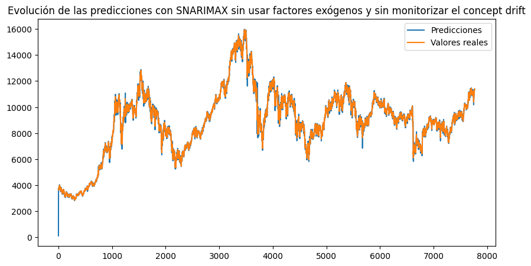

```python
plt.figure(figsize=(10, 5))
plt.plot(df_results_no_exo_no_adwin.prediccion, label='Predicciones')
plt.plot(df_results_no_exo_no_adwin.real, label='Valores reales')
plt.legend()
plt.title(f"Evolución de las predicciones con SNARIMAX sin usar factores exógenos y sin monitorizar el concept drift")
plt.show()
```

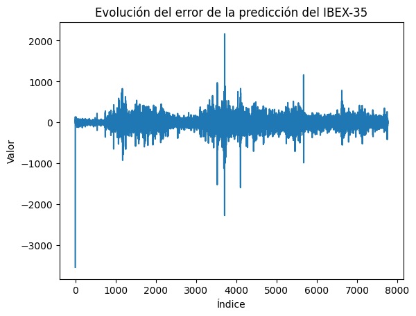

```python
plt.plot(errors_no_exo_no_adwin)

plt.title('Evolución del error de la predicción del IBEX-35')
plt.xlabel('Índice')
plt.ylabel('Valor')
plt.show()
```

**Observaciones**

En general, las predicciones no han diferido significativamente de los valores reales. Aunque en algunos puntos a lo largo de la serie el modelo ha mostrado pequeñas desviaciones, ha logrado ajustarse adecuadamente a los nuevos datos. Al principio, la capacidad de ajuste es notablemente buena. Sin embargo, los errores se han mantenido relativamente estables, aunque con valores algo elevados. En ciertos momentos, se observan errores puntuales muy altos, lo que sugiere que el modelo podría beneficiarse de un mayor ajuste ante cambios abruptos en los datos. Será interesante ver cómo, al monitorizar el concept drift, estos resultados podrían mejorar, ya que la capacidad de adaptación del modelo podría incrementarse al detectar cambios en la distribución de los datos.

## 3.1.2 Predicción sin exógenas y monitorizando el drift con ADWIN

Cargamos los datos.

```python
x_y_no_exo = stream.iter_csv(
    'datos/final_target.csv',
    converters={
        'ibex_close': float
    },
    target='ibex_close'
)
snarimax_no_exo = create_snarimax_model()
```

A continuación, iteramos por los datos y realizamos lo mismo que el método anterior pero en este caso monitorizamos el concept drift con ADWIN.

```python
adwin_no_exo = ADWIN(delta=0.002, clock=1, max_buckets=100, min_window_length=10, grace_period=10)

df_results_dict = {'prediccion': [], 'real': []}
errors_no_exo = []
count = 0
mae = metrics.MAE()
mape = metrics.MAPE()
mse = metrics.MSE()
rmse = metrics.RMSE()
r2 = metrics.R2()
drifts_index = []

for x, y in x_y_no_exo:
    count += 1

    forecast = snarimax_no_exo.forecast(horizon=1, xs=[x])
    mae.update(y, forecast[0])
    mape.update(y, forecast[0])
    mse.update(y, forecast[0])
    rmse.update(y, forecast[0])
    r2.update(y, forecast[0])

    error = forecast[0] - y

    adwin_no_exo.update(error)
    errors_no_exo.append(error)

    if adwin_no_exo.drift_detected:
        snarimax_no_exo = create_snarimax_model()
        drifts_index.append(count)
        print("El modelo se reentrena!!", count)

    df_results_dict['prediccion'].append(forecast[0])
    df_results_dict['real'].append(y)

    snarimax_no_exo.learn_one(y, x)

df_results_no_exo = pd.DataFrame(df_results_dict)
new_result = {
    'modelo': 'SNARIMAX_no_exo_si_adwin',
    'mae': mae.get(),
    'mse': mse.get(),
    'rmse': rmse.get(),
    'mape': mape.get(),
    'r2': r2.get(),
}
new_row_df = pd.DataFrame([new_result])
results_df = pd.concat([results_df, new_row_df], ignore_index=True)
```

```
El modelo se reentrena!! 838
```

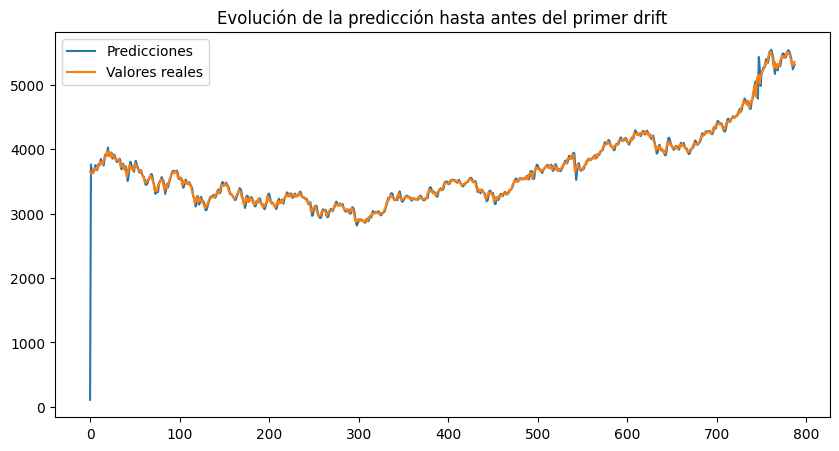

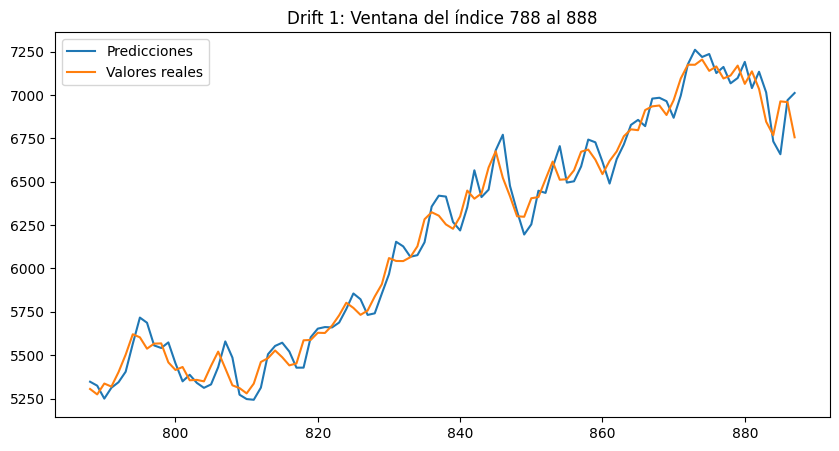

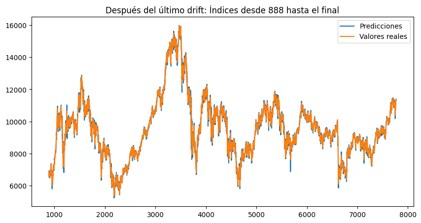

```python
get_predictions_plots(df_results_no_exo, drifts_index)
```

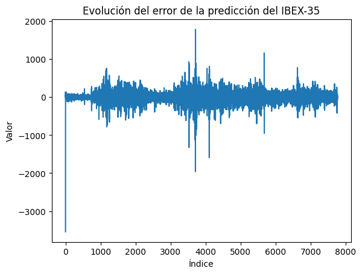

```python
plt.plot(errors_no_exo)

plt.title('Evolución del error de la predicción del IBEX-35')
plt.xlabel('Índice')
plt.ylabel('Valor')
plt.show()
```

**Observaciones**

En este caso, las predicciones han mostrado una mejora respecto a los resultados anteriores. Sin embargo, los errores siguen mostrando un patrón similar. Cuando ocurren cambios en la serie, el modelo tarda en adaptarse adecuadamente, lo que provoca un aumento en los errores.

Es posible que esos errores atípicos no se acumulen de forma coherente para que ADWIN los interprete como un cambio real en la distribución. Este tipo de cambios solo se detectan cuando hay una tendencia clara a lo largo de varias instancias, y no simplemente en unos pocos errores aislados.

En resumen, aunque la predicción en general ha sido buena, se han observado algunos errores relativamente altos. El modelo se adapta bien a los cambios, pero la detección de drifts puntuales podría mejorar, ya que el algoritmo ADWIN no siempre captura cambios abruptos cuando son transitorios.

## 3.1.3 Predicción con 4 exógenas y monitorizando el drift con ADWIN

Cargamos los datos.

```python
x_y_w4_exo = stream.iter_csv(
    'datos/final_deuda_shifted.csv',
    converters={
        'ibex_close': float,
        'tasa_desempleo': float,
        'prima': float,
        'pib_trim_per_capita': float,
        'deuda_perc_pib': float
    },
    target='ibex_close'
)
snarimax_w4 = create_snarimax_model()
```

A continuación, aplicamos el mismo procedimiento que en el caso anterior, pero incorporamos cuatro factores exógenos adicionales al modelo. En este escenario, simulamos que, al finalizar cada jornada bursátil, el modelo predice el cierre del IBEX-35 del día siguiente. La predicción se basa en los factores exógenos registrados durante el día actual, junto con el valor de cierre del IBEX-35. Al día siguiente, actualizamos el modelo utilizando los factores exógenos del día anterior y el valor de cierre más reciente, manteniendo así un enfoque adaptativo y continuo en el aprendizaje.

```python
adwin_w4 = ADWIN(delta=0.002, clock=1, max_buckets=100, min_window_length=10, grace_period=10)

df_results_dict = {'prediccion': [], 'real': []}
errors_w4 = []
count = 0
mae = metrics.MAE()
mape = metrics.MAPE()
mse = metrics.MSE()
rmse = metrics.RMSE()
r2 = metrics.R2()
drifts_index = []
for x, y in x_y_w4_exo:
    count += 1

    forecast = snarimax_w4.forecast(horizon=1, xs=[x])
    mae.update(y, forecast[0])
    mape.update(y, forecast[0])
    mse.update(y, forecast[0])
    rmse.update(y, forecast[0])
    r2.update(y, forecast[0])

    error = forecast[0] - y

    adwin_w4.update(error)
    errors_w4.append(error)

    if adwin_w4.drift_detected:
        snarimax_w4 = create_snarimax_model()
        drifts_index.append(count)
        print("El modelo se reentrena!!", count)

    df_results_dict['prediccion'].append(forecast[0])
    df_results_dict['real'].append(y)

    snarimax_w4.learn_one(y, x)

df_results_w4 = pd.DataFrame(df_results_dict)
new_result = {
    'modelo': 'SNARIMAX_w4_si_adwin',
    'mae': mae.get(),
    'mse': mse.get(),
    'rmse': rmse.get(),
    'mape': mape.get(),
    'r2': r2.get(),
}
new_row_df = pd.DataFrame([new_result])
results_df = pd.concat([results_df, new_row_df], ignore_index=True)
```

```
El modelo se reentrena!! 705
```

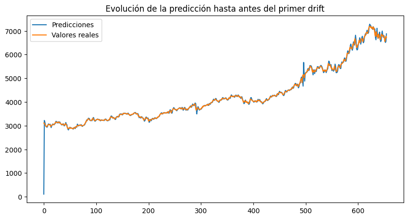

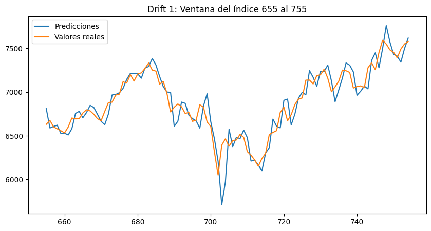

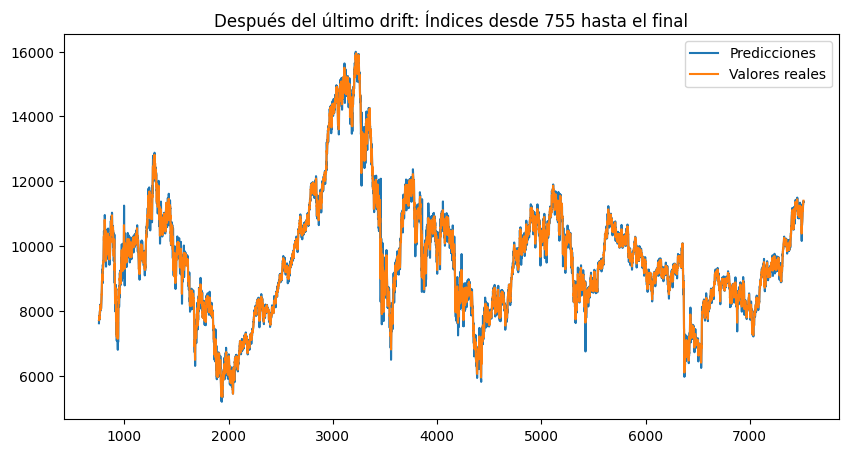

```python
get_predictions_plots(df_results_w4, drifts_index)
```

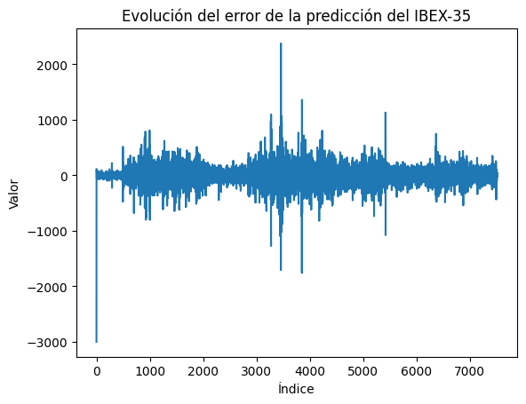

```python
plt.plot(errors_w4)

plt.title('Evolución del error de la predicción del IBEX-35')
plt.xlabel('Índice')
plt.ylabel('Valor')
plt.show()
```

**Observaciones**

El rendimiento observado es similar al del modelo anterior. Sin embargo, parece que los errores han aumentado. Es posible que los factores exógenos estén introduciendo más ruido en el modelo, lo que podría estar dificultando la predicción precisa del cierre del IBEX-35. Esto sugiere que, en este caso, los factores adicionales no están contribuyendo de manera significativa a mejorar la predicción.

## 3.1.4 Predicción con 3 exógenas y monitorizando el drift con ADWIN

Cargamos los datos.

```python
x_y_w3_exo = stream.iter_csv(
    'datos/final_df_shifted.csv',
    converters={
        'ibex_close': float,
        'tasa_desempleo': float,
        'prima': float,
        'pib_trim_per_capita': float
    },
    target='ibex_close'
)
snarimax_w3 = create_snarimax_model()
```

Seguimos con el mismo procedimiento que el anterior, pero usando 3 factores exógenos en este caso.

```python
adwin_w3 = ADWIN(delta=0.002, clock=1, max_buckets=100, min_window_length=10, grace_period=10)

df_results_dict = {'prediccion': [], 'real': []}
errors_w3 = []
count = 0
mae = metrics.MAE()
mape = metrics.MAPE()
mse = metrics.MSE()
rmse = metrics.RMSE()
r2 = metrics.R2()

for x, y in x_y_w3_exo:
    count += 1

    forecast = snarimax_w3.forecast(horizon=1, xs=[x])

    mae.update(y, forecast[0])
    mape.update(y, forecast[0])
    mse.update(y, forecast[0])
    rmse.update(y, forecast[0])
    r2.update(y, forecast[0])

    error = forecast[0] - y

    adwin_w3.update(error)
    errors_w3.append(error)

    if adwin_w3.drift_detected:
        snarimax_w3 = create_snarimax_model()
        print("El modelo se reentrena!!", count)

    df_results_dict['prediccion'].append(forecast[0])
    df_results_dict['real'].append(y)

    snarimax_w3.learn_one(y, x)

df_results_w3 = pd.DataFrame(df_results_dict)
new_result = {
    'modelo': 'SNARIMAX_w3_si_adwin',
    'mae': mae.get(),
    'mse': mse.get(),
    'rmse': rmse.get(),
    'mape': mape.get(),
    'r2': r2.get(),
}
new_row_df = pd.DataFrame([new_result])
results_df = pd.concat([results_df, new_row_df], ignore_index=True)
```

```
El modelo se reentrena!! 875
```

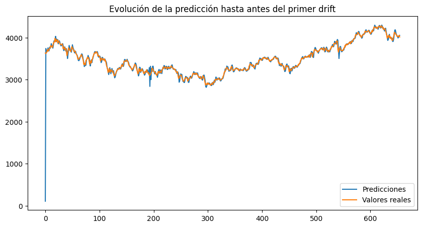

[figure not shown]

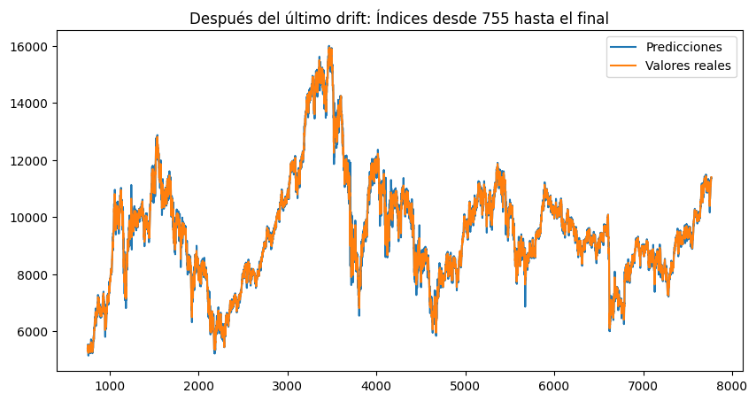

```python
get_predictions_plots(df_results_w3, drifts_index)
```

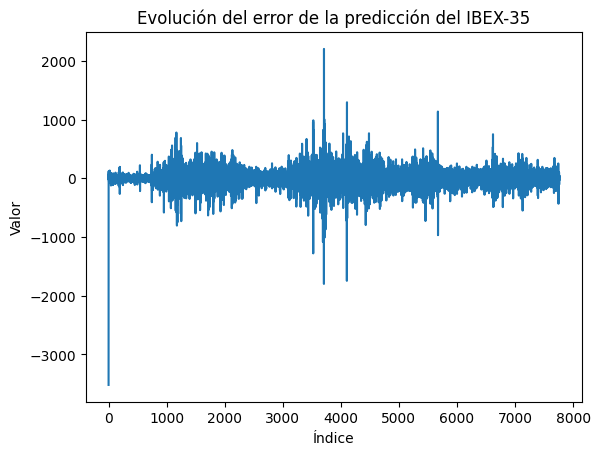

```python
plt.plot(errors_w3)

plt.title('Evolución del error de la predicción del IBEX-35')
plt.xlabel('Índice')
plt.ylabel('Valor')
plt.show()
```

**Observciones**

Observamos que al reducir a tres el número de factores exógenos, el error disminuye ligeramente. Sin embargo, no se observa una mejora significativa en el rendimiento si lo comparamos con la predicción univariada, que solo considera el valor pasado del cierre del IBEX-35.

## 3.1.5 Predicción con 3 exógenas sin monitorizar el drift

Cargamos los datos.

```python
x_y_w3_exo = stream.iter_csv(
    'datos/final_df_shifted.csv',
    converters={
        'ibex_close': float,
        'tasa_desempleo': float,
        'prima': float,
        'pib_trim_per_capita': float
    },
    target='ibex_close'
)
snarimax_w3_no_adwin = create_snarimax_model()
```

Seguimos intentando predecir el valor de cierre del IBEX-35, pero en este caso usamos 3 factores exógenos y no intentamos monitorizar el concept drift.

```python
df_results_dict = {'prediccion': [], 'real': []}
errors_w3_no_adwin = []
count = 0
mae = metrics.MAE()
mape = metrics.MAPE()
mse = metrics.MSE()
rmse = metrics.RMSE()
r2 = metrics.R2()

for x, y in x_y_w3_exo:
    count += 1

    forecast = snarimax_w3_no_adwin.forecast(horizon=1, xs=[x])
    mae.update(y, forecast[0])
    mape.update(y, forecast[0])
    mse.update(y, forecast[0])
    rmse.update(y, forecast[0])
    r2.update(y, forecast[0])

    error = forecast[0] - y

    errors_w3_no_adwin.append(error)

    df_results_dict['prediccion'].append(forecast[0])
    df_results_dict['real'].append(y)

    snarimax_w3_no_adwin.learn_one(y, x)

df_results_w3_no_adwin = pd.DataFrame(df_results_dict)
new_result = {
    'modelo': 'SNARIMAX_w3_no_adwin',
    'mae': mae.get(),
    'mse': mse.get(),
    'rmse': rmse.get(),
    'mape': mape.get(),
    'r2': r2.get(),
}
new_row_df = pd.DataFrame([new_result])
results_df = pd.concat([results_df, new_row_df], ignore_index=True)
```

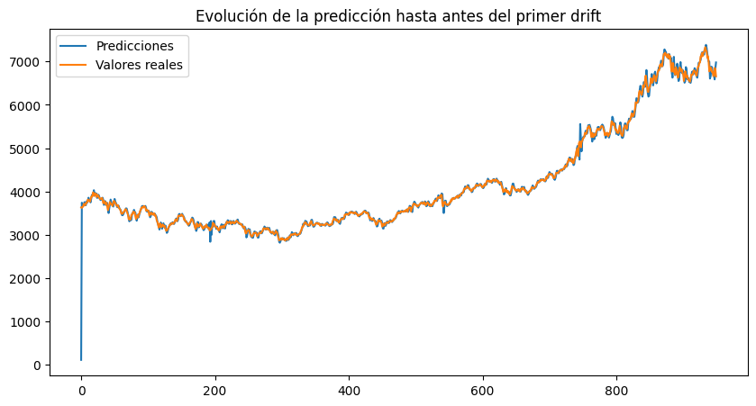

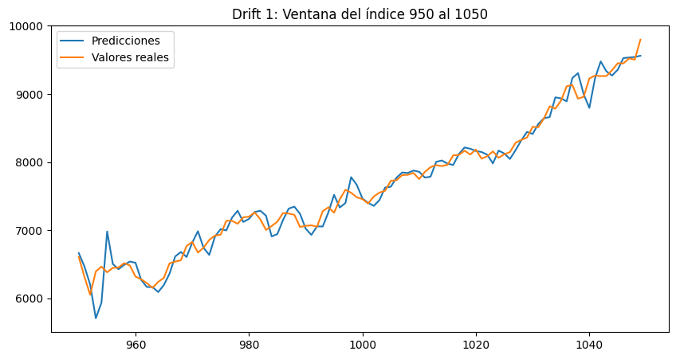

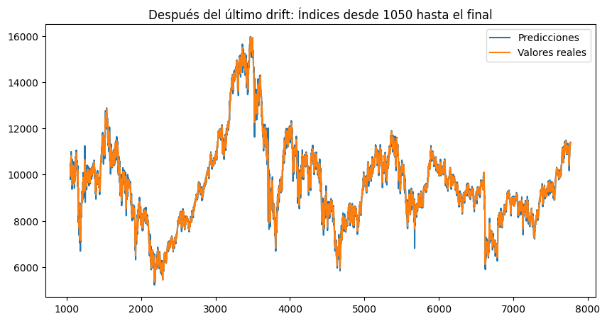

```python
get_predictions_plots(df_results_w3_no_adwin, [1000])
```

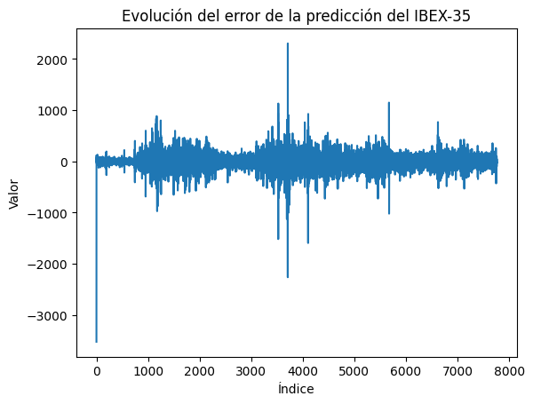

```python
plt.plot(errors_w3_no_adwin)

plt.title('Evolución del error de la predicción del IBEX-35')
plt.xlabel('Índice')
plt.ylabel('Valor')
plt.show()
```

**Observaciones**

## 3.1.6 Predicción con 3 exógenas monitorizando el drift con KSWIN

Cargamos los datos.

```python
x_y_w3_exo = stream.iter_csv(
    'datos/final_df_shifted.csv',
    converters={
        'ibex_close': float,
        'tasa_desempleo': float,
        'prima': float,
        'pib_trim_per_capita': float
    },
    target='ibex_close'
)
snarimax_w3_kswin = create_snarimax_model()
```

Realizamos el mismo procedimiento que el anterior, pero en este caso monitorizamos el drift con KSWIN.

```python
kswin_w3 = KSWIN(alpha=0.002, seed=42, window_size=300, stat_size=50)

df_results_dict = {'prediccion': [], 'real': []}
errors_w3_kswin = []
count = 0
drifts_index = []

for x, y in x_y_w3_exo:
    count += 1

    forecast = snarimax_w3_kswin.forecast(horizon=1, xs=[x])
    mae.update(y, forecast[0])
    mape.update(y, forecast[0])
    mse.update(y, forecast[0])
    rmse.update(y, forecast[0])
    r2.update(y, forecast[0])

    error = forecast[0] - y
    errors_w3_kswin.append(error)

    kswin_w3.update(error)

    if kswin_w3.drift_detected:
        snarimax_w3_kswin = create_snarimax_model()
        drifts_index.append(count)
        print(f"El modelo se reentrena en el índice {count} debido a un drift detectado")


    df_results_dict['prediccion'].append(forecast[0])
    df_results_dict['real'].append(y)

    snarimax_w3_kswin.learn_one(y, x)

df_results_w3_kswin = pd.DataFrame(df_results_dict)

new_result = {
    'modelo': 'SNARIMAX_w3_si_kswin',
    'mae': mae.get(),
    'mse': mse.get(),
    'rmse': rmse.get(),
    'mape': mape.get(),
    'r2': r2.get(),
}
new_row_df = pd.DataFrame([new_result])
results_df = pd.concat([results_df, new_row_df], ignore_index=True)
```

```
El modelo se reentrena en el índice 1363 debido a un drift detectado
El modelo se reentrena en el índice 3136 debido a un drift detectado
El modelo se reentrena en el índice 6659 debido a un drift detectado
```

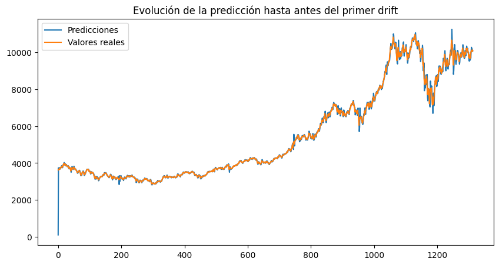

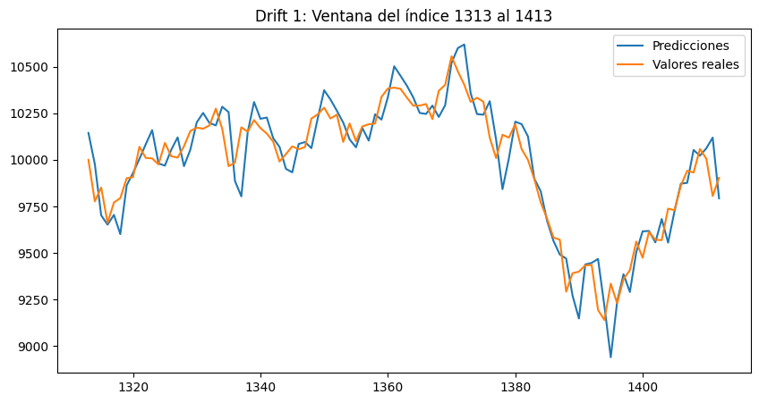

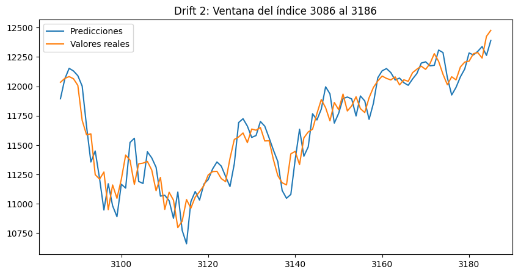

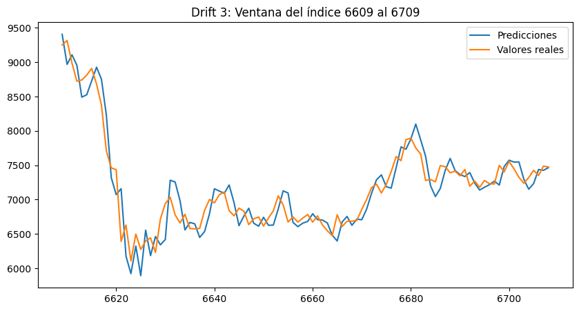

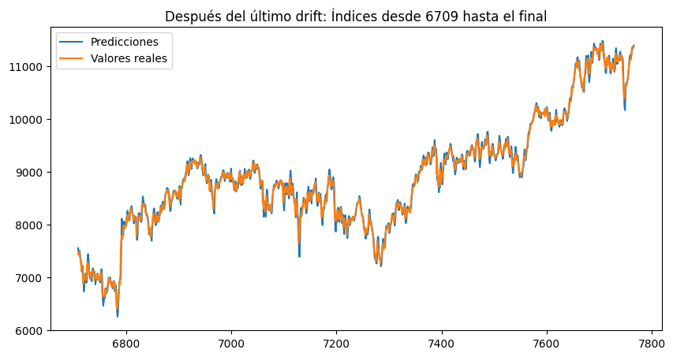

```python
get_predictions_plots(df_results_w3_no_adwin, drifts_index)
```

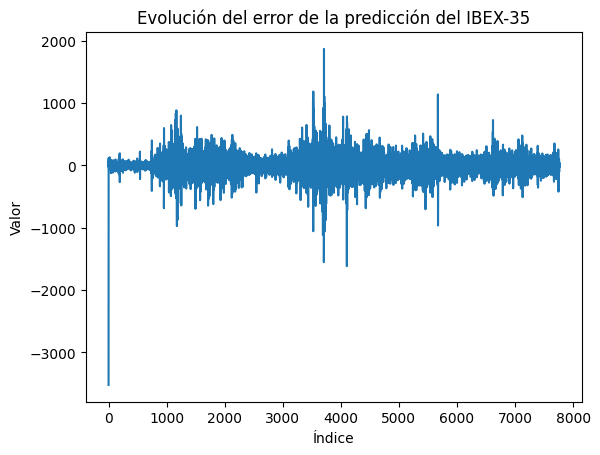

```python
plt.plot(errors_w3_kswin)

plt.title('Evolución del error de la predicción del IBEX-35')
plt.xlabel('Índice')
plt.ylabel('Valor')
plt.show()
```

**Observaciones**

## 3.2 Holt Winters

- **Nivel**: Representa el promedio o estado base de la serie en un momento dado.
- **Tendencia**: Captura cambios persistentes en la dirección de los datos.
- **Estacionalidad**: Refleja patrones repetitivos en intervalos regulares.
- **Multiplicatividad**: Tiene en cuenta si la serie es aditiva o multiplicativa.

Como nuestras series son multiplicativas y tienen tendencia, se ha configurado los parámetros del algoritmo de la siguiente manera:

- **alpha = 0.3**: Con alpha se controla el suavizado del nivel. En nuestro caso, se ha optado por responder a los cambios recientes en el nivel de manera moderada.
- **beta = 0.1**: beta permite ajustar la suavización de la tendencia. Un valor bajo permite estabilizar la tendencia.
- **gamma = 0.6**: gamma determina el peso de la estacionalidad. En el caso de valores altos se permite una adaptación rápida a cambios en patrones estacionales. Como en nuestro caso, los patrones pueden cambiar frecuentemente, se ha optado por poner un valor moderado alto para dar mayor peso a los cambios recientes en los patrones estacionales.
- **multiplicative = True**: El parámetro multiplicativo se refiere a que el cambio de uno puede afectar a la magnitud del otro lag. En nuestro caso, el cierre del IBEX-35 es multiplicativa y por eso se ha seleccionado como True este parámetro.

## 3.2.1 Predicción con 3 exógenas sin monitorización del drift

Cargamos los datos.

```python
x_y_w3_exo = stream.iter_csv(
    'datos/final_df_shifted.csv',
    converters={
        'ibex_close': float,
        'tasa_desempleo': float,
        'prima': float,
        'pib_trim_per_capita': float
    },
    target='ibex_close'
)
winters_w3_kswin = time_series.HoltWinters(
    alpha=0.3,
    beta=0.1,
    gamma=0.6,
    multiplicative=True
)
```

Realizamos las predicciones con Holt Winters, usando 3 factores exógenos y sin tener en cuenta el concept drift.

```python
df_results_dict = {'prediccion': [], 'real': []}
errors_w3_hw = []
count = 0
mae = metrics.MAE()
mape = metrics.MAPE()
mse = metrics.MSE()
rmse = metrics.RMSE()
r2 = metrics.R2()

for x, y in x_y_w3_exo:
    count += 1

    if count >12:

        forecast = winters_w3_kswin.forecast(horizon=1, xs=x)[0]
        mae.update(y, forecast)
        mape.update(y, forecast)
        mse.update(y, forecast)
        rmse.update(y, forecast)
        r2.update(y, forecast)
        winters_w3_kswin.learn_one(y, x)
        error = forecast - y
        errors_w3_hw.append(error)

        df_results_dict['prediccion'].append(forecast)
        df_results_dict['real'].append(y)
    else:
        winters_w3_kswin.learn_one(y, x)


df_results_w3_hw = pd.DataFrame(df_results_dict)

new_result = {
    'modelo': 'Holt_Winters_no_drift',
    'mae': mae.get(),
    'mse': mse.get(),
    'rmse': rmse.get(),
    'mape': mape.get(),
    'r2': r2.get(),
}
new_row_df = pd.DataFrame([new_result])
results_df = pd.concat([results_df, new_row_df], ignore_index=True)
```

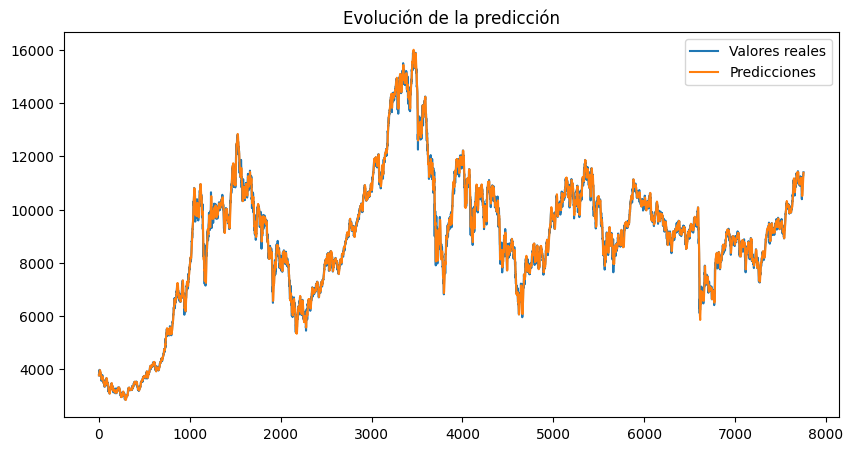

```python
plt.figure(figsize=(10, 5))
plt.plot(df_results_w3_hw.real, label='Valores reales')
plt.plot(df_results_w3_hw.prediccion, label='Predicciones')

plt.legend()
plt.title(f"Evolución de la predicción")
plt.show()
```

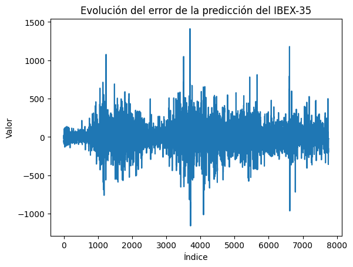

```python
plt.plot(errors_w3_hw)

plt.title('Evolución del error de la predicción del IBEX-35')
plt.xlabel('Índice')
plt.ylabel('Valor')
plt.show()
```

**Observaciones**

Al utilizar el algoritmo de Holt-Winters, se observa que no hay errores atípicos como en otros modelos, lo cual puede explicarse por la naturaleza del suavizado exponencial.

Sin embargo, a pesar de los errores más bajos, se puede notar que, en promedio, los valores de error siguen siendo ligeramente más elevados que en la predicción univariada con SNARIMAX, especialmente cuando se tiene en cuenta el concept drift. Esto sugiere que, aunque el modelo de Holt-Winters pueda ser adecuado, su capacidad de adaptación a cambios abruptos en la distribución de los datos podría no ser tan eficiente como otros enfoques más específicos para el manejo de drifts, como el modelo SNARIMAX.

# 4. Resultados

```python
pd.options.display.float_format = '{:.3f}'.format

results_df
```

|  | modelo | mae | mse | rmse | mape | r2 |
| --- | --- | --- | --- | --- | --- | --- |
| 0 | SNARIMAX_no_exo_no_adwin | 107.912 | 26654.242 | 163.261 | 1.234 | 0.996 |
| 1 | SNARIMAX_no_exo_si_adwin | 107.030 | 25745.295 | 160.453 | 1.224 | 0.996 |
| 2 | SNARIMAX_w4_si_adwin | 117.966 | 30608.037 | 174.952 | 1.324 | 0.994 |
| 3 | SNARIMAX_w3_si_adwin | 112.114 | 28439.134 | 168.639 | 1.285 | 0.996 |
| 4 | SNARIMAX_w3_no_adwin | 111.574 | 28399.252 | 168.521 | 1.279 | 0.996 |
| 5 | SNARIMAX_w3_si_kswin | 112.015 | 28344.643 | 168.359 | 1.283 | 0.996 |
| 6 | Holt_Winters_no_drift | 123.485 | 29752.873 | 172.490 | 1.411 | 0.995 |

En este análisis, se muestran los resultados de varias configuraciones de modelos predictivos aplicados a un problema de series temporales, con el objetivo de predecir el valor de cierre del IBEX-35 en función de diferentes factores y métodos de monitoreo del drift. Las métricas clave de desempeño son el MAE (Error Absoluto Medio), el MSE (Error Cuadrático Medio), el RMSE (Raíz del Error Cuadrático Medio), el MAPE (Error Absoluto Porcentual Medio) y el R² (Coeficiente de Determinación). A continuación, se detallan los resultados obtenidos para cada modelo.

**SNARIMAX_no_exo_no_adwin**

Este modelo no incorpora factores exógenos ni utiliza monitoreo de drift (ADWIN ni KSWIN), lo que lo hace más simple y autónomo. A pesar de esta simplicidad, presenta un rendimiento notablemente fuerte con un R² de 0.996, lo que significa que explica el 99.6% de la variabilidad en los datos observados.

El MAE de 107.912 indica que, en promedio, las predicciones difieren de los valores reales en aproximadamente 108 puntos. Es un valor un poco elevado, dado que estamos trabajando con datos financieros.

El MSE y el RMSE, de 26,654.242 y 163.261 respectivamente, reflejan la magnitud de los errores, penalizando más los valores atípicos. En este caso, también son bastante elevados.

Finalmente, el MAPE es del 1.234%, lo que significa que las predicciones son muy precisas en términos porcentuales, manteniéndose por debajo del umbral del 2%. Esto significa que, aunque las diferencias absolutas son considerables, el modelo es robusto para identificar tendencias y patrones dentro de los datos.

**SNARIMAX_no_exo_si_adwin**

Este modelo no utiliza factores exógenos, pero incorpora monitoreo de drift mediante ADWIN. Aunque la adición de ADWIN mejora la capacidad del modelo para detectar y adaptarse a cambios conceptuales en los datos, el rendimiento sigue siendo muy fuerte, con un R² de 0.996, lo que indica que el modelo explica el 99.6% de la variabilidad de los datos.

El MAE de 107.030 sugiere que, en promedio, las predicciones se desvían de los valores reales en aproximadamente 107 puntos, lo cual es relativamente alto en un contexto financiero, aunque es comparable con el modelo anterior.

El MSE y el RMSE, de 25,745.295 y 160.453 respectivamente, siguen siendo altos, lo que refleja la sensibilidad del modelo a los errores más grandes y la existencia de posibles valores atípicos en los datos.

El MAPE de 1.224% indica que el modelo sigue siendo muy preciso en términos porcentuales, manteniéndose también por debajo del 2%. Esto demuestra que el modelo es efectivo a la hora de predecir las tendencias, incluso con la inclusión de ADWIN.

**SNARIMAX_w4_si_adwin**

En este modelo, se incorporan cuatro factores exógenos junto con el monitoreo de drift mediante ADWIN. A pesar de los esfuerzos por incorporar más variables para mejorar las predicciones, el rendimiento muestra un pequeño descenso en comparación con los modelos anteriores. El R² es de 0.994, lo que sigue siendo muy alto, pero indica que el modelo ahora explica un 99.4% de la variabilidad en los datos, ligeramente menos que los modelos sin factores exógenos.

El MAE de 117.966 refleja un incremento en el error promedio, con las predicciones desviándose en aproximadamente 118 puntos en promedio, lo cual podría considerarse algo elevado en términos financieros.

El MSE y RMSE, de 30,608.037 y 174.952 respectivamente, son más altos que en los modelos anteriores, lo que sugiere que las adiciones de factores exógenos aumentan la complejidad del modelo y pueden introducir más ruido, afectando su rendimiento general.

El MAPE de 1.324% sigue siendo inferior al 2%, lo que sugiere que, a pesar de la mayor complejidad del modelo, las predicciones siguen siendo bastante precisas en términos relativos.

**SNARIMAX_w3_si_adwin**

Este modelo incorpora tres factores exógenos y el monitoreo de drift con ADWIN. Al igual que el modelo con cuatro factores exógenos, la inclusión de estos factores mejora la flexibilidad del modelo, pero la capacidad predictiva es ligeramente inferior en comparación con los modelos sin factores exógenos. El R² de 0.996 sigue siendo muy alto, indicando una excelente capacidad para explicar la variabilidad en los datos.

El MAE de 112.114 sugiere que las predicciones difieren en promedio por 112 puntos de los valores reales. Aunque sigue siendo alto en términos absolutos, este error es comparable al de otros modelos con monitoreo de drift y factores exógenos.

El MSE de 28,439.134 y el RMSE de 168.639 son altos, reflejando la sensibilidad del modelo a errores más grandes y mostrando que la inclusión de factores exógenos introduce más variabilidad.

El MAPE de 1.285% indica que el modelo sigue siendo bastante preciso en términos porcentuales, manteniéndose bajo el 2% y demostrando que es efectivo para identificar las tendencias en los datos.

**SNARIMAX_w3_no_adwin**

Este modelo utiliza tres factores exógenos sin monitoreo de drift, lo que lo hace menos adaptable a cambios conceptuales en los datos en comparación con los modelos con ADWIN. A pesar de esta limitación, el modelo sigue teniendo un rendimiento sólido, con un R² de 0.996, lo que indica que es capaz de explicar el 99.6% de la variabilidad de los datos.

El MAE de 111.574 muestra que las predicciones difieren en promedio por 112 puntos de los valores reales, lo que es similar al modelo con monitoreo de drift, lo que sugiere que la ausencia de ADWIN no tiene un impacto significativo en el error promedio.

El MSE y el RMSE, de 28,399.252 y 168.521 respectivamente, siguen siendo relativamente altos, lo que refleja que el modelo tiene dificultades para ajustarse completamente a los datos y que las diferencias en los valores reales y predichos son notables.

El MAPE de 1.279% es ligeramente mejor que en otros modelos, indicando que el modelo, aunque no tan adaptable a los cambios, sigue siendo bastante preciso en términos relativos.

**SNARIMAX_w3_si_kswin**

Este modelo incorpora tres factores exógenos junto con monitoreo de drift utilizando KSWIN. Al agregar KSWIN, el modelo es capaz de adaptarse a los cambios en los datos, pero su desempeño sigue siendo comparable a otros modelos con monitoreo de drift. El R² de 0.996 sugiere que el modelo sigue siendo muy efectivo en la explicación de la variabilidad de los datos.

El MAE de 112.015 indica que las predicciones difieren en promedio por 112 puntos de los valores reales, lo cual es coherente con otros modelos similares en términos de error absoluto.

El MSE y el RMSE, de 28,344.643 y 168.359 respectivamente, son similares a los modelos anteriores, lo que refleja que la adición de KSWIN no ha reducido significativamente la magnitud de los errores, aunque puede haber mejorado la capacidad del modelo para manejar los cambios en los datos.

El MAPE de 1.283% sigue siendo bastante bajo, lo que demuestra que, en términos porcentuales, las predicciones siguen siendo muy precisas.

**Holt_Winters_no_drift**

El MAE de 123.485 muestra que las predicciones difieren en promedio por 123 puntos de los valores reales, lo que es un poco más alto que en los modelos SNARIMAX. Este valor es un indicativo de que el modelo tiene más dificultades para ajustarse a los datos de manera precisa.

El MSE de 29,752.873 y el RMSE de 172.490 reflejan una penalización más alta por los errores más grandes, lo que sugiere que el modelo tiene dificultades para manejar ciertos valores atípicos o errores significativos.

El MAPE de 1.411% es más alto en comparación con los otros modelos, lo que indica que las predicciones en términos porcentuales son algo menos precisas, pero aún se mantienen dentro de un rango razonable.

# 5. Conclusiones

A lo largo de este análisis de predicción con aprendizaje incremental para series temporales del IBEX-35, se han probado diferentes configuraciones de modelos con y sin factores exógenos, y con monitoreo de drift mediante técnicas como ADWIN y KSWIN. Los resultados obtenidos reflejan el rendimiento variado de estos modelos, donde el SNARIMAX_no_exo_si_ADWIN ha destacado como el modelo con mejor desempeño global.

El modelo SNARIMAX sin exógenas y con monitorización del concept drift con ADWIN ha mostrado el mejor rendimiento con un R² de 0.996, lo que significa que explica el 99.6% de la variabilidad de los datos. Este rendimiento es comparable al de los modelos más complejos, pero con la ventaja de no requerir factores exógenos. El monitoreo de drift mediante ADWIN ha sido crucial para que el modelo se adapte correctamente a los cambios en la distribución de los datos a lo largo del tiempo. El MAE de 107.030 indica que las predicciones, en promedio, difieren de los valores reales en aproximadamente 107 puntos, lo cual, si bien sigue siendo relativamente alto en un contexto financiero, demuestra una capacidad de predicción bastante precisa en comparación con otros modelos. Los valores de MSE (25,745.295) y RMSE (160.453) también son más bajos que los de otros modelos, lo que refleja una menor penalización por los errores de predicción, especialmente durante los períodos de alta volatilidad. Además, el MAPE de 1.224% indica que el modelo es bastante preciso en términos porcentuales, manteniéndose bien por debajo del umbral del 2%.

Aunque el SNARIMAX_no_exo_si_ADWIN ha demostrado un excelente rendimiento general, el MAE sigue siendo relativamente elevado. Esto sugiere que, en promedio, las predicciones podrían aún diferir significativamente de los valores reales, lo que podría tener un impacto importante en decisiones financieras si las predicciones son utilizadas para operar en el mercado. Por lo tanto, es recomendable trabajar en la mejora de la precisión de las predicciones, especialmente durante días atípicos o con alta volatilidad.

A pesar de los resultados del MAE, sería interesante poner en producción el modelo e ir viendo como evoluciona en el tiempo. En este sentido, al ser un algoritmo incremental, se podrían añadir otros factores exógenos que pudiesen ayudar a capturar más la variabilidad en los datos. O también, se podrían explorar otras líneas de monitoreo del drift.

En conclusión, SNARIMAX_no_exo_si_ADWIN ha mostrado ser el modelo más robusto y preciso, a pesar de no utilizar factores exógenos. Esto destaca la importancia de monitorear el drift en los datos a lo largo del tiempo, permitiendo al modelo adaptarse y mantenerse preciso incluso frente a cambios en la distribución de los datos. Las áreas de mejora incluyen la incorporación de factores exógenos, la optimización del monitoreo de drift y la mejora de la precisión en situaciones de alta volatilidad. Las investigaciones futuras podrían centrarse en estos aspectos para obtener un modelo aún más eficaz en la predicción de los movimientos del IBEX-35.